# Maximum likelihood

14 Dec 2014

## Maximum Likelihood estimation

For a particular statistical model, **maximum likelihood** finds the set of *parameters* (the intercept and the coefficients for example) that make the observed data **most likely to have occurred**

These estimated parameters are thus the **Maximum likelihood estimates** of our statistical model.

For linear regression, the maximum likelihood estimates, are equivalent to the ordinary least squares estimates.

## Maximum likelihood

**Frogs in Lakes**

n = 11 *Total number of visited lakes*  
y = 7 *Lakes with frogs*  
(n-y) = 4 *Lakes without frogs*

p *Probability to find a frog in a lake*  
(1-p) *Probabilty not to find a frog*

\(L\) \(\alpha\) \(ppppppp(1-p)(1-p)(1-p)(1-p)\)

\(L\) \(\alpha\) \(p^y (1-p)^{(n-y)}\)

\(L\) \(\alpha\) \(p^7 (1-p)^4\)

\(L(p|n,y)= \frac{n!}{y!(n-y)!}p^y (1-p)^{(n-y)}\)

## Maximum likelihood

\(L(p|n,y)= \frac{n!}{y!(n-y)!}p^y (1-p)^{(n-y)}\)

```r
f<-factorial(11)/(factorial(7)*factorial(4))
p<-0.5
L<-f*p^7*(1-p)^4
```

## Maximum likelihood

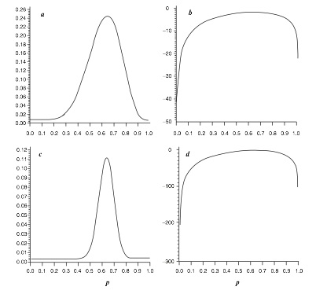

Likelihood (p=0.5) = 0.1611  
Likelihood (p=0.7) = 0.2201  
Likelihood (p=0.8) = 0.1107

## Maximum likelihood

```r
storks.dat<-read.csv("storks.csv")
storks.lm<-lm(Birth~Storks, data=storks.dat)
```

```r
summary(storks.lm)
```

```
##
## Call:
## lm(formula = Birth ~ Storks, data = storks.dat)
##
## Residuals:
##    Min     1Q Median     3Q    Max
##   -479   -166   -145     -2    631
##
## Coefficients:
##             Estimate Std. Error t value Pr(>|t|)
## (Intercept) 225.0287    93.5606    2.41   0.0295 *
## Storks        0.0288     0.0094    3.06   0.0079 **
## ---
## Signif. codes:  0 '***' 0.001 '**' 0.01 '*' 0.05 '.' 0.1 ' ' 1
##
## Residual standard error: 332 on 15 degrees of freedom
## Multiple R-squared:  0.385,  Adjusted R-squared:  0.344
## F-statistic: 9.38 on 1 and 15 DF,  p-value: 0.0079
```

## Maximum likelihood

```r
logLik(storks.lm)
```

```
## 'log Lik.' -121.8 (df=3)
```

## Maximum likelihood

```r
storks.glm<-glm(Birth~Storks, data=storks.dat)
```

```r
summary(storks.glm)
```

## Maximum likelihood

```
##
## Call:
## glm(formula = Birth ~ Storks, data = storks.dat)
##
## Deviance Residuals:
##    Min      1Q  Median      3Q     Max
##   -479    -166    -145      -2     631
##
## Coefficients:
##             Estimate Std. Error t value Pr(>|t|)
## (Intercept) 225.0287    93.5606    2.41   0.0295 *
## Storks        0.0288     0.0094    3.06   0.0079 **
## ---
## Signif. codes:  0 '***' 0.001 '**' 0.01 '*' 0.05 '.' 0.1 ' ' 1
##
## (Dispersion parameter for gaussian family taken to be 110347)
##
##     Null deviance: 2690208  on 16  degrees of freedom
## Residual deviance: 1655206  on 15  degrees of freedom
## AIC: 249.5
##
## Number of Fisher Scoring iterations: 2
```

## Maximum likelihood

```r
logLik(storks.glm)
```

```
## 'log Lik.' -121.8 (df=3)
```

## Generalized Linear Models

We can use generalized linear models to model dependent variables with non normal distribution of their errors (Binomial, Poisson, etc.).

Formulation is the same as for the linear model, but a link-function links the (linear) relationship between the covariates and the response variable with error distribution different than normal.

**Binomial model (Logistic regression)**

\(logit(p) = \alpha + \beta_{1} X_{1i} + \beta_{2} X_{2i} + \epsilon_{i}\)

\(logit(p) = log(\frac{p}{1-p})\)

## Logistic regression

http://lizmartinresearch.wordpress.com/2013/12/02/beginners-r-generalized-linear-models/

http://ww2.coastal.edu/kingw/statistics/R-tutorials/logistic.html

## Modeling count data with glm

http://www.petrkeil.com/?p=1709